# Anoop EDA

Anoop Thirthahalli Sundaresh

# 1 Exploratory Data Analysis

## 1.1 Importing Data

```r
setwd("~/EDA ")
#include all packages

# raw.df <- read.csv("C:/Users/Owner/Downloads/test_dataset.csv")
raw.df <-read.csv(file.choose())
head(raw.df)
```

|  | Outcome | V1 | V2 | V3 | V4 | V5 | V6 | V7 | V8 | V9 |
| --- | --- | --- | --- | --- | --- | --- | --- | --- | --- | --- |
| 1 | 0 | 19 | 182 | 1 | 0 | 0 | 0 | 1 | 0 | 523 |
| 2 | 0 | 33 | 155 | 2 | 0 | 0 | 0 | 0 | 3 | 551 |
| 3 | 0 | 20 | 105 | 0 | 1 | 0 | 0 | 0 | 1 | 557 |
| 4 | 0 | 21 | 108 | 0 | 1 | 0 | 0 | 1 | 2 | 594 |
| 5 | 0 | 18 | 107 | 0 | 1 | 0 | 0 | 1 | 0 | 600 |
| 6 | 0 | 21 | 124 | 2 | 0 | 0 | 0 | 0 | 0 | 622 |

```r
str(raw.df)
```

```
## 'data.frame':    189 obs. of  10 variables:
##  $ Outcome: int  0 0 0 0 0 0 0 0 0 0 ...
##  $ V1     : int  19 33 20 21 18 21 22 17 29 26 ...
##  $ V2     : int  182 155 105 108 107 124 118 103 123 113 ...
##  $ V3     : int  1 2 0 0 0 2 0 2 0 0 ...
##  $ V4     : int  0 0 1 1 1 0 0 0 1 1 ...
##  $ V5     : int  0 0 0 0 0 0 0 0 0 0 ...
##  $ V6     : int  0 0 0 0 0 0 0 0 0 0 ...
##  $ V7     : int  1 0 0 1 1 0 0 0 0 0 ...
##  $ V8     : int  0 3 1 2 0 0 1 1 1 0 ...
##  $ V9     : int  523 551 557 594 600 622 637 637 663 665 ...
```

```r
summary(raw.df)
```

```
##     Outcome             V1              V2              V3
##  Min.   :0.0000   Min.   :14.00   Min.   : 80.0   Min.   :0.0000
##  1st Qu.:0.0000   1st Qu.:19.00   1st Qu.:110.0   1st Qu.:0.0000
##  Median :0.0000   Median :23.00   Median :121.0   Median :0.0000
##  Mean   :0.3122   Mean   :23.24   Mean   :129.9   Mean   :0.8466
##  3rd Qu.:1.0000   3rd Qu.:26.00   3rd Qu.:140.2   3rd Qu.:2.0000
##  Max.   :1.0000   Max.   :45.00   Max.   :250.0   Max.   :2.0000
##                                   NA's   :1
##        V4               V5               V6                V7
##  Min.   :0.0000   Min.   :0.0000   Min.   :0.00000   Min.   :0.0000
##  1st Qu.:0.0000   1st Qu.:0.0000   1st Qu.:0.00000   1st Qu.:0.0000
##  Median :0.0000   Median :0.0000   Median :0.00000   Median :0.0000
##  Mean   :0.3915   Mean   :0.1958   Mean   :0.06349   Mean   :0.1481
##  3rd Qu.:1.0000   3rd Qu.:0.0000   3rd Qu.:0.00000   3rd Qu.:0.0000
##  Max.   :1.0000   Max.   :3.0000   Max.   :1.00000   Max.   :1.0000
##
##        V8               V9
##  Min.   :0.0000   Min.   :-1291.0
##  1st Qu.:0.0000   1st Qu.:  414.0
##  Median :0.0000   Median :  977.0
##  Mean   :0.7937   Mean   :  944.6
##  3rd Qu.:1.0000   3rd Qu.: 1487.0
##  Max.   :6.0000   Max.   : 2990.0
##
```

```r
# CONVERSION INTO FACTORS
#Outcomne and v3 to V8#
clean.df<-raw.df
cols <- c("V3", "V4", "V5", "V6","V7","V8","Outcome")
clean.df[cols] <- lapply(clean.df[cols], as.factor)
summary(clean.df)
```

```
##  Outcome       V1              V2        V3     V4      V5      V6
##  0:130   Min.   :14.00   Min.   : 80.0   0:96   0:115   0:159   0:177
##  1: 59   1st Qu.:19.00   1st Qu.:110.0   1:26   1: 74   1: 24   1: 12
##          Median :23.00   Median :121.0   2:67           2:  5
##          Mean   :23.24   Mean   :129.9                  3:  1
##          3rd Qu.:26.00   3rd Qu.:140.2
##          Max.   :45.00   Max.   :250.0
##                          NA's   :1
##  V7      V8            V9
##  0:161   0:100   Min.   :-1291.0
##  1: 28   1: 47   1st Qu.:  414.0
##          2: 30   Median :  977.0
##          3:  7   Mean   :  944.6
##          4:  4   3rd Qu.: 1487.0
##          6:  1   Max.   : 2990.0
##
```

V3,V4,V5,V6 ,V7 and V8 are converted into categorical Variables Also,we have one missing value in V2

## 1.2 Checking Distribution and Imputaion

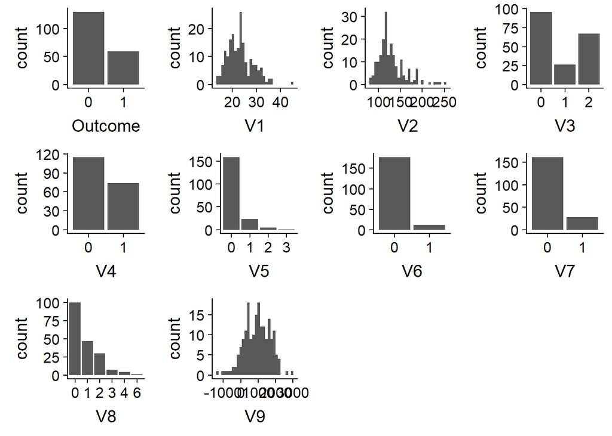

```r
my_plots <- lapply(names(clean.df), function(var_x){
  p <-
    ggplot(clean.df) +
    aes_string(var_x)

  if(is.numeric(clean.df[[var_x]])) {
    p <- p + geom_histogram()

  } else {
    p <- p + geom_bar()
  }

})


plot_grid(plotlist = my_plots)
```

```r
clean.df$V2[is.na(clean.df$V2)] <- median(clean.df$V2, na.rm=TRUE)
```

## 1.3 Examining relations between the various continuous variables

We can first begin by examining the correlation between the continuous variables

```r
correlations <- rcorr(cbind(clean.df$V1,clean.df$V2,clean.df$V9), type ='pearson')
correlations
```

```
##      [,1] [,2] [,3]
## [1,] 1.00 0.18 0.09
## [2,] 0.18 1.00 0.19
## [3,] 0.09 0.19 1.00
##
## n= 189
##
##
## P
##      [,1]   [,2]   [,3]
## [1,]        0.0132 0.2165
## [2,] 0.0132        0.0105
## [3,] 0.2165 0.0105
```

Based on the result we can see that using 189 samples we can conclude that V1 and V2 have a positive and statistically significant correlation. However using the value we can conclude that it is a weak correlation.

The correlation between V2 and V9 is also positive and statistically significant. However using the value we can conclude that it is a weak correlation.

The correlation between V1 and V9 is not statistically significant hence we can dedcue that they are not corelated.

## 1.4 Examining the relations of the continuous variables with outcome

### 1.4.1 Graphical analysis

We will start this analysis by plotting these relations using box-plots

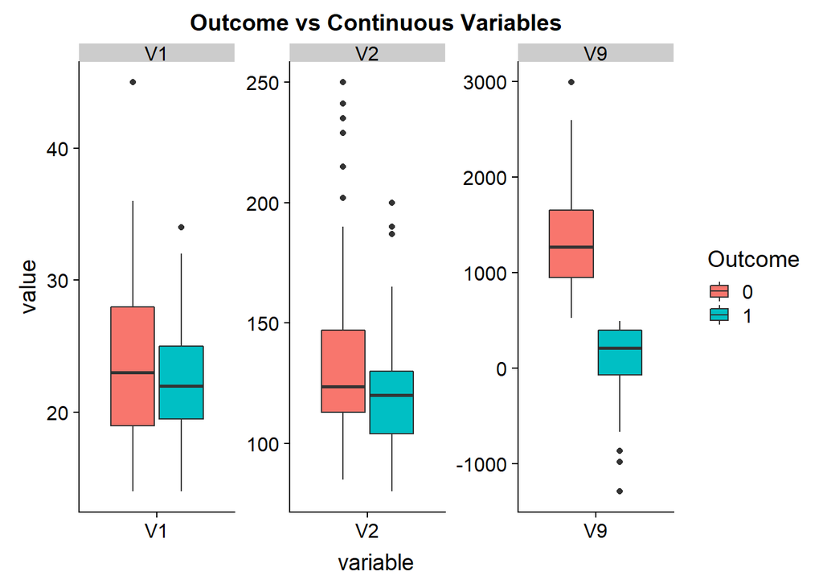

```r
new_bb <- filter(clean.df[, cbind(1,2,3,10)])
updatedbb <- melt(new_bb, id.vars = 'Outcome')

ggplot(data = updatedbb, aes(x=variable, y=value)) + geom_boxplot(aes(fill=Outcome)) +
  facet_wrap( ~ variable, scales = "free") + ggtitle("Outcome vs Continuous Variables")
```

From the above graphs we can see that the values for V1 and V2 do not change based on the Outcome value much. But, the values for V9 change with the Outcome value.

### 1.4.2 Statistical analysis

We will now statistically analyze whether the box-plot results are statistically significant or not using the t-test

```r
t.test(clean.df$V1 ~ clean.df$Outcome, conf.level = 0.95)
```

```
##
##  Welch Two Sample t-test
##
## data:  clean.df$V1 by clean.df$Outcome
## t = 1.7737, df = 136.94, p-value = 0.07834
## alternative hypothesis: true difference in means is not equal to 0
## 95 percent confidence interval:
##  -0.1558349  2.8687423
## sample estimates:
## mean in group 0 mean in group 1
##        23.66154        22.30508
```

As you can see from the p-value of this test, the difference between the means for V1 values are not statistically different for 0 and 1 value of outcome.

This confirms that V1 is not varying with respect to outcome and hence just by using V1 we cannot predict the values for Outcome.

Similarly we will run a test for V2:

```r
t.test(clean.df$V2 ~ clean.df$Outcome, conf.level = 0.95)
```

```
##
##  Welch Two Sample t-test
##
## data:  clean.df$V2 by clean.df$Outcome
## t = 2.5155, df = 132.46, p-value = 0.01308
## alternative hypothesis: true difference in means is not equal to 0
## 95 percent confidence interval:
##   2.38552 19.94329
## sample estimates:
## mean in group 0 mean in group 1
##        133.3000        122.1356
```

We now run the test for our last continuous varaible V9:

```r
t.test(clean.df$V9 ~ clean.df$Outcome, conf.level = 0.95)
```

```
##
##  Welch Two Sample t-test
##
## data:  clean.df$V9 by clean.df$Outcome
## t = 18.67, df = 135.45, p-value < 2.2e-16
## alternative hypothesis: true difference in means is not equal to 0
## 95 percent confidence interval:
##  1101.292 1362.246
## sample estimates:
## mean in group 0 mean in group 1
##      1329.10769        97.33898
```

Based on the p-value we can see that there is statistically significant difference between the means for teh values of V9 for 0 and 1 values of Outcome.

This confirms our results from box plot that the value of outcome is Impacted by V9.

## 1.5 Examining the relations between continuous and categorical variables

To do so we can use the ANOVA method:

First we do ANOVA full model, meaning, it includes all the categorical variables and their interactions

```r
m1 <- aov(V9 ~ V3*V4*V5*V6*V7*V8, data = clean.df)
summary(m1)
```

[output not shown]

From the p-value of the results we see that most of the interactions are not statistically significant and the variable V8 is not significant.

This means they play no role in the variation of the values in variable V9. So we can now remove them and run the ANOVA again to get the actually siginificant variables.

Eliminating the non-significant terms:

```r
m2 <- aov(V9 ~ V3 + V4 + V5 + V6 + V7 + V3:V4:V6 , data = clean.df)
summary(m2)
```

```
##              Df   Sum Sq Mean Sq F value   Pr(>F)
## V3            2  5015725 2507863   6.226  0.00245 **
## V4            1  7322575 7322575  18.179 3.29e-05 ***
## V5            3  3637832 1212611   3.011  0.03164 *
## V6            1  1544653 1544653   3.835  0.05180 .
## V7            1  7217380 7217380  17.918 3.73e-05 ***
## V3:V4:V6      6  5145367  857561   2.129  0.05232 .
## Residuals   174 70086123  402794
## ---
## Signif. codes:  0 '***' 0.001 '**' 0.01 '*' 0.05 '.' 0.1 ' ' 1
```

From the above results we can conculde that V3, V4, V5, V7 contribute to the variation in V9 with a 95% confidence interval

## 1.6 chi-square test for testing independence between categorical variable

```r
chisq.test(clean.df$V3, clean.df$V4)
```

```
##
##  Pearson's Chi-squared test
##
## data:  clean.df$V3 and clean.df$V4
## X-squared = 21.779, df = 2, p-value = 1.865e-05
```

```r
chisq.test(clean.df$V3, clean.df$V5)
```

```
##
##  Pearson's Chi-squared test
##
## data:  clean.df$V3 and clean.df$V5
## X-squared = 2.625, df = 6, p-value = 0.8542
```

```r
chisq.test(clean.df$V3, clean.df$V6)
```

```
##
##  Pearson's Chi-squared test
##
## data:  clean.df$V3 and clean.df$V6
## X-squared = 1.4038, df = 2, p-value = 0.4956
```

```r
chisq.test(clean.df$V3, clean.df$V7)
```

```
##
##  Pearson's Chi-squared test
##
## data:  clean.df$V3 and clean.df$V7
## X-squared = 0.85322, df = 2, p-value = 0.6527
```

```r
chisq.test(clean.df$V3, clean.df$V8)
```

```
##
##  Pearson's Chi-squared test
##
## data:  clean.df$V3 and clean.df$V8
## X-squared = 8.8669, df = 10, p-value = 0.5448
```

```r
chisq.test(clean.df$V4, clean.df$V5)
```

```
##
##  Pearson's Chi-squared test
##
## data:  clean.df$V4 and clean.df$V5
## X-squared = 7.2046, df = 3, p-value = 0.06565
```

```r
chisq.test(clean.df$V4, clean.df$V6)
```

```
##
##  Pearson's Chi-squared test with Yates' continuity correction
##
## data:  clean.df$V4 and clean.df$V6
## X-squared = 1.6837e-31, df = 1, p-value = 1
```

```r
chisq.test(clean.df$V4, clean.df$V7)
```

```
##
##  Pearson's Chi-squared test with Yates' continuity correction
##
## data:  clean.df$V4 and clean.df$V7
## X-squared = 0.41576, df = 1, p-value = 0.5191
```

```r
chisq.test(clean.df$V4, clean.df$V8)
```

```
##
##  Pearson's Chi-squared test
##
## data:  clean.df$V4 and clean.df$V8
## X-squared = 8.0145, df = 5, p-value = 0.1554
```

```r
chisq.test(clean.df$V5, clean.df$V6)
```

```
##
##  Pearson's Chi-squared test
##
## data:  clean.df$V5 and clean.df$V6
## X-squared = 0.56664, df = 3, p-value = 0.904
```

```r
chisq.test(clean.df$V5, clean.df$V7)
```

```
##
##  Pearson's Chi-squared test
##
## data:  clean.df$V5 and clean.df$V7
## X-squared = 11.27, df = 3, p-value = 0.01035
```

```r
chisq.test(clean.df$V5, clean.df$V8)
```

```
##
##  Pearson's Chi-squared test
##
## data:  clean.df$V5 and clean.df$V8
## X-squared = 11.956, df = 15, p-value = 0.6823
```

```r
chisq.test(clean.df$V6, clean.df$V7)
```

```
##
##  Pearson's Chi-squared test with Yates' continuity correction
##
## data:  clean.df$V6 and clean.df$V7
## X-squared = 1.1512, df = 1, p-value = 0.2833
```

```r
chisq.test(clean.df$V6, clean.df$V8)
```

```
##
##  Pearson's Chi-squared test
##
## data:  clean.df$V6 and clean.df$V8
## X-squared = 3.5728, df = 5, p-value = 0.6124
```

```r
chisq.test(clean.df$V7, clean.df$V8)
```

```
##
##  Pearson's Chi-squared test
##
## data:  clean.df$V7 and clean.df$V8
## X-squared = 1.9806, df = 5, p-value = 0.8518
```

## 1.7 chi-square test for testing independence between Outcome and categorical variable

```r
chisq.test(clean.df$Outcome, clean.df$V3)
```

```
##
##  Pearson's Chi-squared test
##
## data:  clean.df$Outcome and clean.df$V3
## X-squared = 5.0048, df = 2, p-value = 0.08189
```

```r
chisq.test(clean.df$Outcome, clean.df$V4)
```

```
##
##  Pearson's Chi-squared test with Yates' continuity correction
##
## data:  clean.df$Outcome and clean.df$V4
## X-squared = 4.2359, df = 1, p-value = 0.03958
```

```r
chisq.test(clean.df$Outcome, clean.df$V5)
```

```
##
##  Pearson's Chi-squared test
##
## data:  clean.df$Outcome and clean.df$V5
## X-squared = 16.864, df = 3, p-value = 0.0007538
```

```r
chisq.test(clean.df$Outcome, clean.df$V6)
```

```
##
##  Pearson's Chi-squared test with Yates' continuity correction
##
## data:  clean.df$Outcome and clean.df$V6
## X-squared = 3.1431, df = 1, p-value = 0.07625
```

```r
chisq.test(clean.df$Outcome, clean.df$V7)
```

```
##
##  Pearson's Chi-squared test with Yates' continuity correction
##
## data:  clean.df$Outcome and clean.df$V7
## X-squared = 4.4227, df = 1, p-value = 0.03546
```

```r
chisq.test(clean.df$Outcome, clean.df$V8)
```

```
##
##  Pearson's Chi-squared test
##
## data:  clean.df$Outcome and clean.df$V8
## X-squared = 5.987, df = 5, p-value = 0.3075
```

# 2 EDA Summary

All the above EDA findings need to be considered while building the models and interpreting the results